# Series de tiempo univaridas

Examen final (Práctica)

Michel Mendivenson Barragán Zabala

mbarraganz@unal.edu.co

Cesar Augusto Prieto Sarmiento

ceprieto@unal.edu.co

2024-09-21

## **Lectura de los datos**

Considere la serie de tiempo mensual que le correspondió del archivo del archivo `Base_de_datos_Parcial.xslx` las cuales están relacionadas a temáticas de empleo/desempleo en Estados Unidos y Colombia. Asuma la siguiente configuración para los datos: los datos de entrenamiento van desde el mes donde esté el primer dato hasta diciembre de del año 2021, los datos de validación corresponden desde enero de 2022 hasta diciembre de 2022, mientras que los datos de prueba van desde enero de 2023 hasta abril de 2024.

```r
ts = ts(rnorm(100))
```

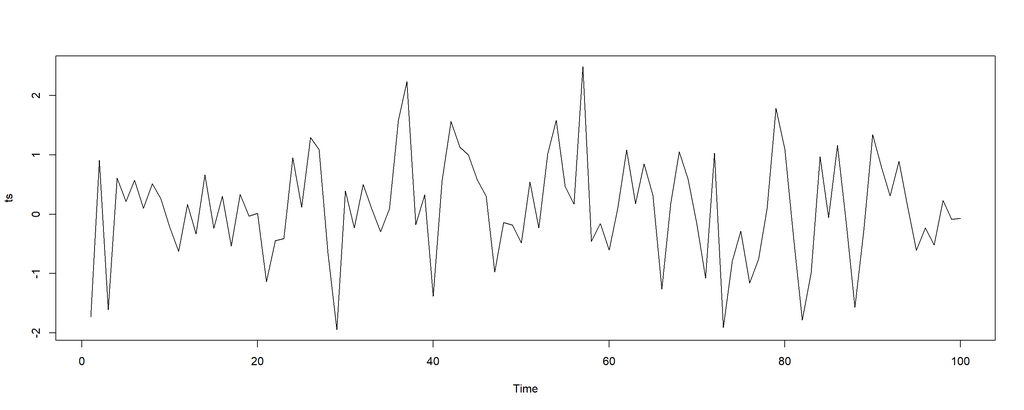

```r
plot(ts)
```

# Punto 1: Haga una análisis descriptivo de la serie de tiempo, es decir, realice todos los análisis necesarios para detectar las posibles características que tiene presente la serie. ¿Qué puede usted observar al respecto?

# Punto 2: Ajuste 2 modelos para la serie de tiempo indicada: un modelo de Redes Neuronales (multicapa o recurrentes) para resolver el problema de la predicción 2 pasos adelante, y un modelo *(S)ARIMA* (puede incluir una variable dummy o de Fourier) (**obligatorio**).

En el caso de redes neuronales o redes neuronales recurrentes, se debe explorar (mediante *grid search*) capas ocultas (1 o 2), cada capa oculta con 8 o 32 nodos o neuronas, y con función de activación *tanh* o *ReLU* (el tamaño del lote debe ser igual a 10, el algoritmo de optimización que usted crea conveniente, al igual que la tasa de aprendizaje, y el número de *epochs* no debe ser menor a 50). No olviden usar el conjunto de validación para identificar los hiperparámetros de cada modelo.

En caso de que el modelo no tenga hiperparámetros, unir el conjunto de entrenamiento y validación como un solo conjunto de entrenamiento.

**Observación:** Para el modelo de redes neuronales, indicar las características o variables explicativas del modelo y cómo fueron seleccionadas. Adicionalmente, indique todo el procedimiento de identificación del modelo de la familia S(ARIMA). Debe modelar los *outliers* para el modelo SARIMA si alguno fue detectado. Tenga en cuenta que puede usar las variables de intervención obtenidas para el modelo SARIMA cuando modele los *outliers* en el modelo de redes.

## MODELO DE REDES NEURONALES LSTM

A continuacion, se describe el procedimiento llevado a cabo para ajustar un modelo de redes neuronales recurrentes (RNN) en este caso un modelo LSTM, con el objetivo de predecir la tasa de desempleo de mujeres en Colombia, empleando variables adicionales a los datos historicos obtenidos del profesor. Se ha diseñado el modelo para realizar predicciones a dos pasos adelante, incorporando técnicas de preprocesamiento y ajuste de hiperparámetros, el desarollo de este modelo fue realizado en un cuardeno de Jupyter Notebook, usando python y los paquetes que ahí se proporcionan.

### ELECCION DE REZAGOS Y VARIABLES DE FOURIRES

Los rezagos seleccionados fueron los ultimos 12 dado que se observa una tendencia estacional de 12 meses en la serie de tiempo segun los visto en la descomposicion STL y ademas de esto el periodo obtenido fue de 12 meses, por lo que se considero que estos rezagos podrian ser importantes para el ajuste del modelo. Por otra parte, se seleccionaron 4 variables de fourier, dado que se observo que la serie de tiempo presentaba una tendencia estacional de 12 meses, se considero que 4 variables de fourier podrian ser suficientes para capturar esta tendencia. Estas variables de Fourier en terminos de Senos y Cosenos, para una periodicidad anual y mensual respectivamente, las cuales se muestran a continuacion:

```python
# Obtener el índice de la serie de tiempo como un objeto DatetimeIndex
date_time_index = df1.index
date_time_index = pd.Series(date_time_index)

# Convertir cada valor de fecha y hora a un timestamp en segundos
timestamp_s = date_time_index.apply(pd.Timestamp.timestamp)
print(timestamp_s)

# Crear el DataFrame con las variables de Fourier
df2 = pd.DataFrame()
day = 24*60*60  # segundos en un día
year = 365.2425 * day  # segundos en un año (considerando años bisiestos)
month = year / 12

df2['TDMC'] = df1['TDMC'].values
df2['Year sin'] = np.sin(timestamp_s * (2 * np.pi / year))
df2['Year cos'] = np.cos(timestamp_s * (2 * np.pi / year))
df2['Month sin'] = np.sin(timestamp_s * (2 * np.pi / month))
df2['Month cos'] = np.cos(timestamp_s * (2 * np.pi / month))

# Mostrar las primeras filas del DataFrame resultante
print(df2.head())
```

[figure not shown]

Series de Fourier Anual

En la grafica anterior se puede observar como en las variables de Fourier tanto para el seno como para el coseno para el caso de una periodicidad anual es decir 12 tiempos si nos guiamos por el eje x de la figura obtenemos un ciclo completo, lo cual nos esta aportando informacion util sobre como se comporta la serie.

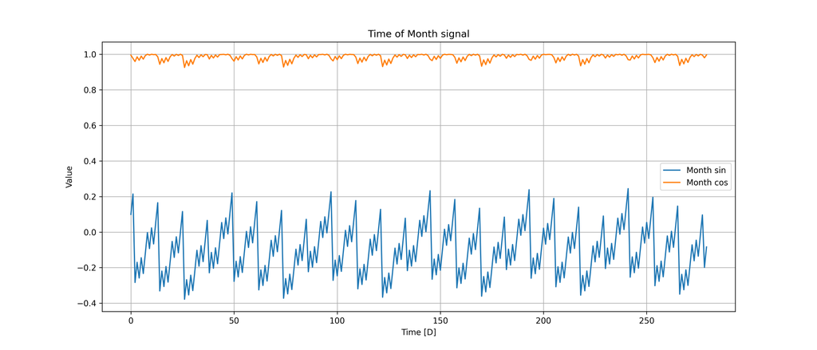

Series de Fourier Mensual

Para el caso mensual, obtenemos resultados distintos a los anuales pero esto no quiere decir que estas caracteristicas no esten siendo informativas, se puede ver tanto para el Seno como para el Coseno, que existe una periodicidad en el comportamiento mensual de la serie.  
Dicho lo anterior, estas son las variables con las variables extra con las que nos proponemos a realizar la aplicacion y el ajuste del modelo de redes neuronales.

Luego se tomaron lo rezagos de la serie de tiempo, para esto se utilizo la funcion de pandas `shift` para obtener los rezagos de la serie de tiempo, y a su vez tambien se hizo el ajuste para resolver el problema de la prediccion a 2 pasos adelante. A continuacion se muestra el codigo utilizado para obtener los rezagos de la serie de tiempo.

```python
from pandas import DataFrame

df4 = DataFrame()
df4 = df2
print(df4)

# Crear los rezagos
for lag in range(1, 12 + 1):
    df4[f'TDMC_lag_{lag}'] = df4['TDMC'].shift(lag)

# Desplazar la variable objetivo 2 pasos adelante
df4['TDMC_2_steps_ahead'] = df4['TDMC'].shift(-2)

# Eliminar filas con valores nulos (ocurren debido a los rezagos)
df4.dropna(inplace=True)
df4.head(5)

# Separar las características y la variable objetivo
X = df4.drop(columns=['TDMC', 'TDMC_2_steps_ahead'])
y = df4['TDMC_2_steps_ahead']
```

### DIVISION DE LOS DATOS

Para la division de los datos se utilizo la funcion `.loc` de pandas para seleccionar los datos de entrenamiento, validacion y prueba, se seleccionaro los datos tal cual se indicio en el documento de requerimientos del punto 2, es decir, de la forma en la que se seleccionarion los datos de entrenamiento van desde el mes donde esté el primer dato hasta diciembre de del año 2021, los datos de validación corresponden desde enero de 2022 hasta diciembre de 2022, mientras que los datos de prueba van desde enero de 2023 hasta abril de 2024. A continuacion se muestra el codigo utilizado para la division de los datos.

```python
from sklearn.preprocessing import StandardScaler, MinMaxScaler
from sklearn.model_selection import train_test_split

# Normalizar las características
scaler = MinMaxScaler()
X_scaled = scaler.fit_transform(X)

# Convertir X_scaled de vuelta a DataFrame para mantener el índice temporal
X_scaled = pd.DataFrame(X_scaled, index=df4.index, columns=X.columns)

# Dividir los datos según el rango temporal
X_train = X_scaled.loc[:'2021-12']
y_train = y.loc[:'2021-12']

X_val = X_scaled.loc['2022-01':'2022-12']
y_val = y.loc['2022-01':'2022-12']

X_test = X_scaled.loc['2023-01':'2024-04']
y_test = y.loc['2023-01':'2024-04']
```

### AJUSTE DE LA RED Y DEFINICION DE HIPERPARAMETROS

El proceso de ajuste fue llevado a cabo utilizando `Keras` y `scikit-learn` para estructurar el modelo y realizar la validación cruzada.

```python
# Función para crear el modelo LSTM
def create_model(layers=1, neurons=8, activation='relu', learning_rate=0.001):
    model = Sequential()

    # Primera capa LSTM
    model.add(LSTM(neurons, activation=activation, input_shape=(1, n_features)))

    # Segunda capa LSTM si es necesario
    if layers == 2:
        model.add(LSTM(neurons, activation=activation))

    # Capa de salida
    model.add(Dense(1))  # Una neurona de salida

    # Compilar el modelo
    optimizer = Adam(learning_rate=learning_rate)
    model.compile(optimizer=optimizer, loss='mse')

    return model

model = KerasRegressor(model=create_model, epochs=50, batch_size=10, verbose=0)

# Definimos los hiperparámetros que vamos a probar
param_grid = {
    'model__layers': [1, 2],
    'model__neurons': [8, 32],
    'model__activation': ['tanh', 'relu'],
    'model__learning_rate': [0.001, 0.01],
}

grid = GridSearchCV(estimator=model, param_grid=param_grid, cv=3, scoring='neg_mean_squared_error')
grid_result = grid.fit(X_train_reshaped, y_train)
```

### RESULTADOS DEL AJUSTE DE HIPERPARAMETROS

Con lo anterior, obtuvimos el mejor modelo de redes neuronales LSTM con los siguientes hiperparametros:

```python
Best parameters: {'model__activation': 'tanh', 'model__layers': 1, 'model__learning_rate': 0.01, 'model__neurons': 32}
Best score: -8.418888179783044
```

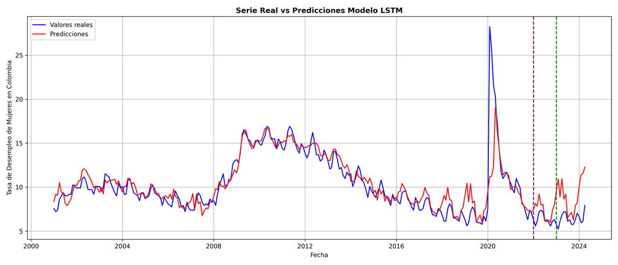

Real vs Predicciones

```python
# Realizar predicciones en cada conjunto
train_predictions = best_model.predict(X_train_reshaped)
val_predictions = best_model.predict(X_val_reshaped)
test_predictions = best_model.predict(X_test_reshaped)

PredT = np.concatenate([train_predictions, val_predictions, test_predictions])
ObsT = np.concatenate([y_train, y_val, y_test])
FechasT = np.concatenate([y_train.index, y_val.index, y_test.index])


plt.figure(figsize=(14, 6))

# Graficar los valores reales y predicciones del conjunto de entrenamiento
plt.plot(FechasT, ObsT , label='Valores reales (Entrenamiento)', linestyle='-', color='blue')
plt.plot(FechasT, PredT, label='Predicciones (Entrenamiento)', linestyle='-', color='red')

split_date_val = y_val.index[0]
plt.axvline(x=split_date_val, color='purple', linestyle='--')
split_date_test = y_test.index[0]
plt.axvline(x=split_date_test, color='green', linestyle='--')

plt.title('Serie Real vs Predicciones Modelo LSTM', fontweight = 'bold', fontsize = 'large')
plt.xlabel('Fecha', fontweight = 'medium', fontsize = 'medium')
plt.ylabel('Tasa de Desempleo de Mujeres en Colombia', fontweight = 'medium', fontsize = 'medium')
plt.grid(True)
plt.tight_layout()
plt.legend(["Valores reales", "Predicciones"], fontsize= 10)

plt.savefig('Real_vs_Pred.png', format='png', dpi=300)  # Ajusta dpi para la calidad
plt.show()
```

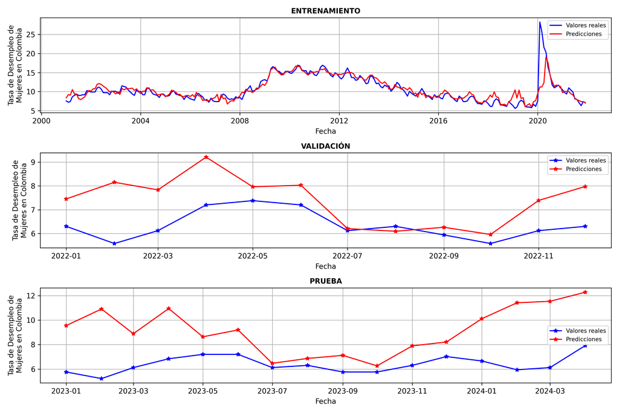

Real vs Predicciones

```python
import matplotlib.pyplot as plt
import numpy as np

# Crear una figura para graficar todos los conjuntos
plt.figure(figsize=(12, 8))

# Graficar los valores reales y predicciones del conjunto de entrenamiento
plt.subplot(3, 1, 1)
plt.plot(y_train.index, y_train, label='Valores reales (Entrenamiento)', linestyle='-', color='blue')
plt.plot(y_train.index, train_predictions, label='Predicciones (Entrenamiento)', linestyle='-', color='red')
plt.title('ENTRENAMIENTO', fontweight = 'bold', fontsize = 'medium')
plt.xlabel('Fecha', fontweight = 'medium', fontsize = 'medium')
plt.ylabel('Tasa de Desempleo de\nMujeres en Colombia', fontweight = 'medium', fontsize = 'medium')
plt.grid(True)
plt.legend(["Valores reales", "Predicciones"], fontsize= 8)

# Graficar los valores reales y predicciones del conjunto de validación
plt.subplot(3, 1, 2)
plt.plot(y_val.index, y_val, label='Valores reales (Validación)', linestyle='-', marker='*', color='blue')
plt.plot(y_val.index, val_predictions, label='Predicciones (Validación)', linestyle='-', marker='*', color='red')
plt.title('VALIDACIÓN', fontweight = 'bold', fontsize = 'medium')
plt.xlabel('Fecha', fontweight = 'medium', fontsize = 'medium')
plt.ylabel('Tasa de Desempleo de\nMujeres en Colombia', fontweight = 'medium', fontsize = 'medium')
plt.grid(True)
plt.legend(["Valores reales", "Predicciones"], fontsize= 8)

# Graficar los valores reales y predicciones del conjunto de prueba
plt.subplot(3, 1, 3)
plt.plot(y_test.index, y_test, label='Valores reales (Prueba)', linestyle='-', marker='*', color='blue')
plt.plot(y_test.index, test_predictions, label='Predicciones (Prueba)', linestyle='-', marker='*', color='red')
plt.title('PRUEBA', fontweight = 'bold', fontsize = 'medium')
plt.xlabel('Fecha', fontweight = 'medium', fontsize = 'medium')
plt.ylabel('Tasa de Desempleo de\nMujeres en Colombia', fontweight = 'medium', fontsize = 'medium')
plt.grid(True)
plt.legend(["Valores reales", "Predicciones"], fontsize= 8)

# Ajustar el layout y mostrar el gráfico
plt.tight_layout()
plt.savefig('Real_vs_Pred2.png', format='png', dpi=300)  # Ajusta dpi para la calidad
plt.show()
```

# Obtenga los residuales de cada modelo ajustado y realice un chequeo de la gráfica, así como de la función de autocorrelación de los residuales. ¿Qué puede usted decir al respecto para cada modelo?

## RESIDUALES PARA EL MODELO DE REDES NEURONALES

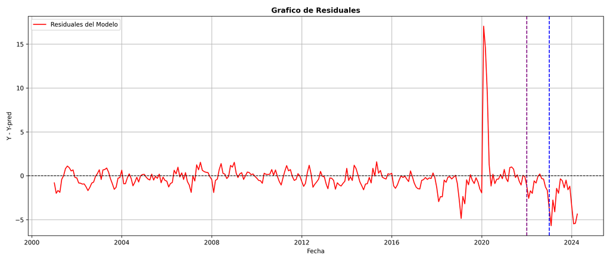

Residuales

```python
residuals_train = y_train - train_predictions
residuals_val = y_val - val_predictions
residuals_test = y_test - test_predictions

Resid = np.concatenate([residuals_train, residuals_val, residuals_test])

plt.figure(figsize=(14, 6))

# Graficar los valores reales y predicciones del conjunto de entrenamiento
plt.plot(FechasT, Resid , label='Residuales del Modelo', linestyle='-', color='red')

split_date_val = y_val.index[0]
plt.axvline(x=split_date_val, color='purple', linestyle='--')
split_date_test = y_test.index[0]
plt.axvline(x=split_date_test, color='blue', linestyle='--')

plt.axhline(y=0, color='black', linestyle='--', linewidth=1)

plt.title('Grafico de Residuales', fontweight = 'bold', fontsize = 'large')
plt.xlabel('Fecha', fontweight = 'medium', fontsize = 'medium')
plt.ylabel('Y - Y-pred', fontweight = 'medium', fontsize = 'medium')
plt.grid(True)
plt.tight_layout()
plt.legend(fontsize= 10)

plt.savefig('Residuales.png', format='png', dpi=300)  # Ajusta dpi para la calidad
plt.show()
```

En la grafica de los residuales podemos observar como estos se mantienen al rededor de 0 en la mayoría de los casos, sin embargo, se observa un comportamiento de los residuales en el conjunto de validación y test, donde se presentan valores atípicos que se alejan de 0.

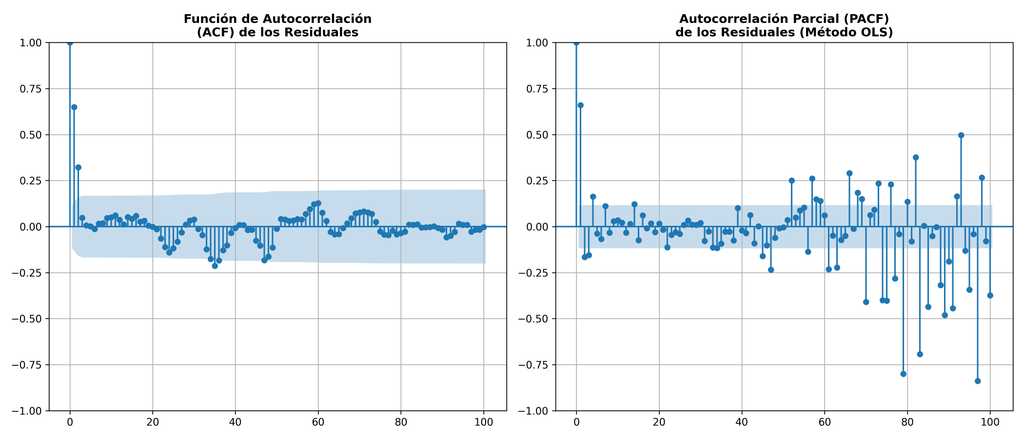

ACF_PACF

```python
from statsmodels.graphics.tsaplots import plot_acf, plot_acf
import matplotlib.pyplot as plt

# ACF de los residuales
plt.figure(figsize=(14, 6))

# Gráfico ACF de los residuales
plt.subplot(1, 2, 1)  # 1 fila, 2 columnas, 1ª posición
plot_acf(Resid, lags=100, ax=plt.gca())
plt.title('Función de Autocorrelación\n(ACF) de los Residuales', fontweight='bold', fontsize='large')
plt.grid(True)

# Gráfico ACF con método OLS
plt.subplot(1, 2, 2)  # 1 fila, 2 columnas, 2ª posición
plot_pacf(Resid, lags=100, method='ols', ax=plt.gca())
plt.title('Autocorrelación Parcial (PACF)\nde los Residuales (Método OLS)', fontweight='bold', fontsize='large')
plt.grid(True)

plt.tight_layout()

plt.savefig('ACF_PACF.png', format='png', dpi=300)  # Ajusta dpi para la calidad
plt.show()
```

- Interpretacion para el grafico de Autocorrelación (ACF) de los Residuales:
  - La presencia de autocorrelaciones significativas, aunque menores, sugiere que incluso el modelo LSTM no ha capturado completamente todos los patrones temporales en los datos.
  - El patrón oscilatorio decreciente podría indicar una estacionalidad residual que el modelo LSTM no ha modelado totalmente.
- Interpretacion para el grafico Autocorrelación Parcial (PACF) de los Residuales:
  - Los picos dispersos y significativos en varios lags indican que aún hay algunas dependencias temporales no lineales que el modelo LSTM no ha capturado completamente.

Basandonos en estos resultados del ACF y PACF, podemos decir que en general, el modelo LSTM parece estar haciendo un trabajo razonable, ya que la mayoría de las autocorrelaciones están dentro de las bandas de confianza. Por otra parte, La presencia de autocorrelaciones residuales sugiere que los datos tienen una estructura temporal muy compleja que incluso una LSTM está teniendo dificultades para capturar completamente

# Obtenga el error cuadrático medio de predicción dos pasos adelante basado en los modelos ajustados del punto anterior y el conjunto de prueba. ¿Cuál modelo escogería basado en este criterio únicamente? Con base en el modelo seleccionado, realice el pronóstico para junio de 2024 con origen de pronóstico en abril de 2024. Recuerde que el modelo que va a usar para hacer el pronóstico final debe ser entrenado con todo el conjunto de datos.

```python
import pandas as pd
from sklearn.metrics import mean_squared_error

# Calcular MSE para cada conjunto
mse_train = mean_squared_error(y_train, train_predictions)
mse_val = mean_squared_error(y_val, val_predictions)
mse_test = mean_squared_error(y_test, test_predictions)
mse_total = mean_squared_error(ObsT, PredT)

# Crear un DataFrame para mostrar los resultados
mse_results = pd.DataFrame({
    'Conjunto': ['Entrenamiento', 'Validación', 'Prueba', 'Total'],
    'MSE': [mse_train, mse_val, mse_test, mse_total]
})

# Mostrar la tabla
print(mse_results)
```

| Conjunto | MSE |
| --- | --- |
| Entrenamiento | 3.161561 |
| Validación | 1.719881 |
| Prueba | 10.874646 |
| Total | 3.540522 |